# Philippine Tech Hackers Salary Survey, part 1

# Introduction

The second Philippine Tech Hackers Salary Survey was conducted online using Google Forms. A total of 507 community members responded, from companies both large and small, and from a wide variety of industries. Respondents were mostly software developers, but other professionals who program and are involved in IT also participated. Outliers, and those who reported as living/working outside the country were excluded from the analysis.

The median monthly base salary for the remaining sample was Php 42,500, with the middle half of all respondents earning between Php 27,500 and Php 77,500

*In the horizontal bar charts throughout this report, we include the interquartile range (IQR) to show the middle 50% of respondents’ answers to questions such as salary. One quarter of the respondents has a salary below the displayed range, and one quarter has a salary above the displayed range. The median salary of Php 42,500 will be represented in the box graphs by a dashed blue line.*

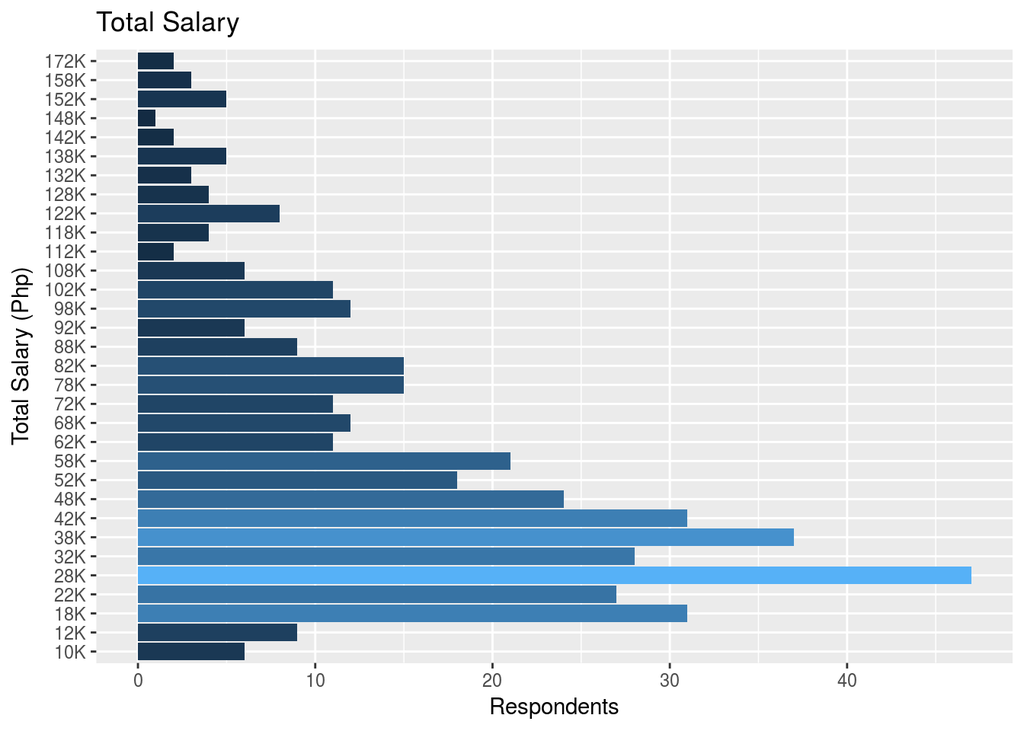

# Location

The overwhelming majority of respondents live and work in Metro Manila, with just over 19.2% of the respondents from other cities in the Philippines. The median salary for respondents living and working in Metro Manila is Php 47,500 with the median outside of NCR Php 10,000 lower at Php 37,500

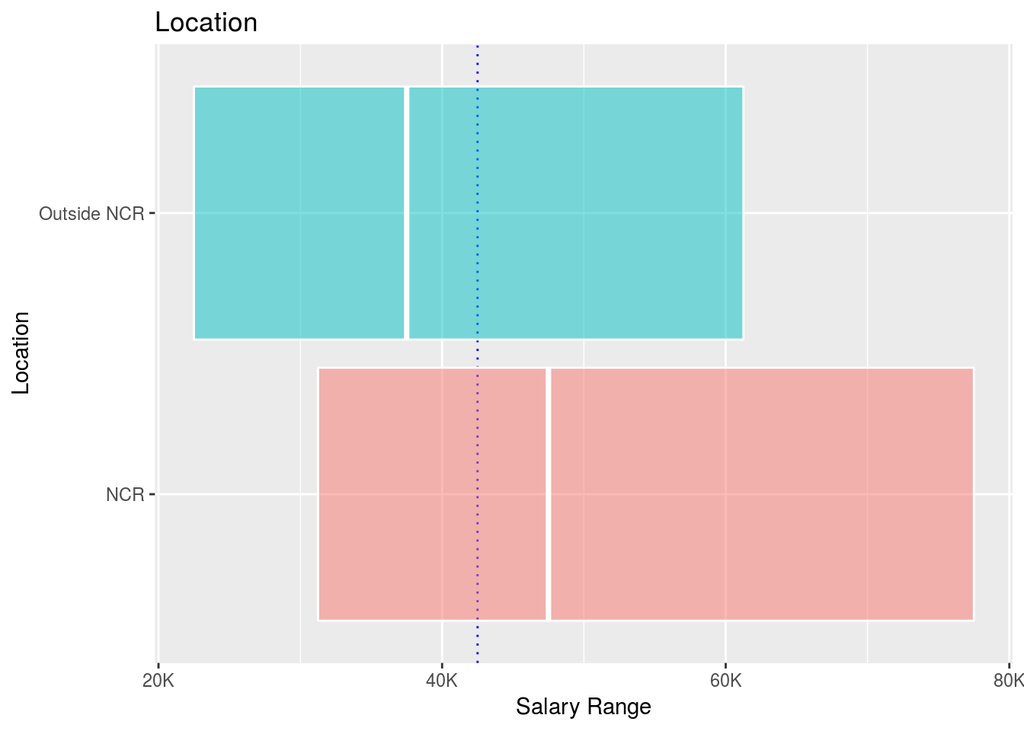

# Company Types

The salary survey included questions on industry, company size, and company age. Software (incl. SaaS, Web, Mobile) was the most well-represented industry (36.4%), followed by Consulting (IT) (14.3%) and Business Process Outsourcing (6.1%).

## Industry Salaries

In terms of salary range, employees in Banking / Finance and Carriers / Telecommunications had the highest median salary at Php 57,500 while Education had the lowest at Php 32,500.

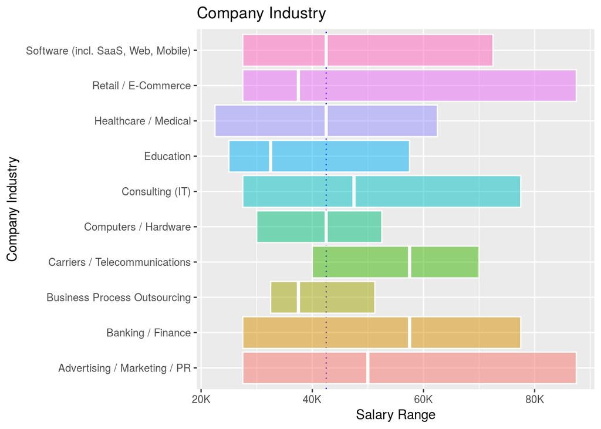

## Company Size

Half the respondents work in companies with 100 or less employees, with 22.5% of respondents working in companies with between 2 and 25 employees. Respondents working in very large companies (over 10,000 employees) made up only 7.51% of the sample.

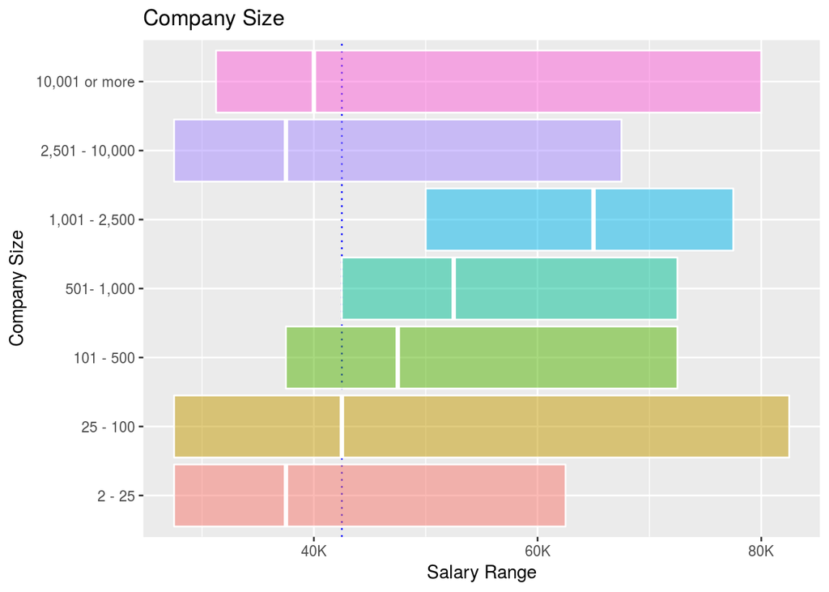

## Company Age

Employees working at companies less than 10 years old made up 57.5% of respondents and reported salaries above the overall median.

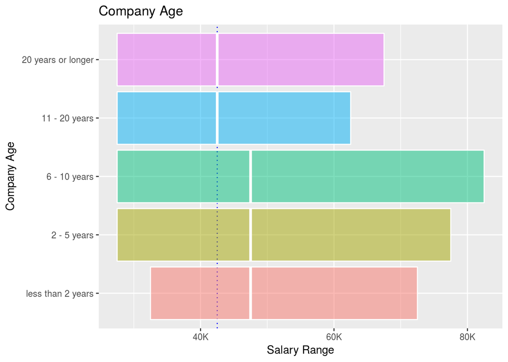

# Team and Project Size

There seems to be no clear relationship between team or project size and salary, other than solo developers and those on very large project teams (greater than 20 members) tend to make less than the overall median salary.

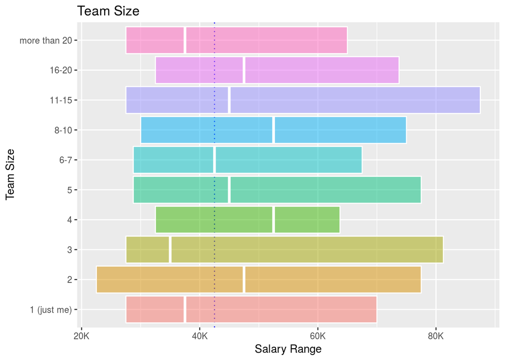

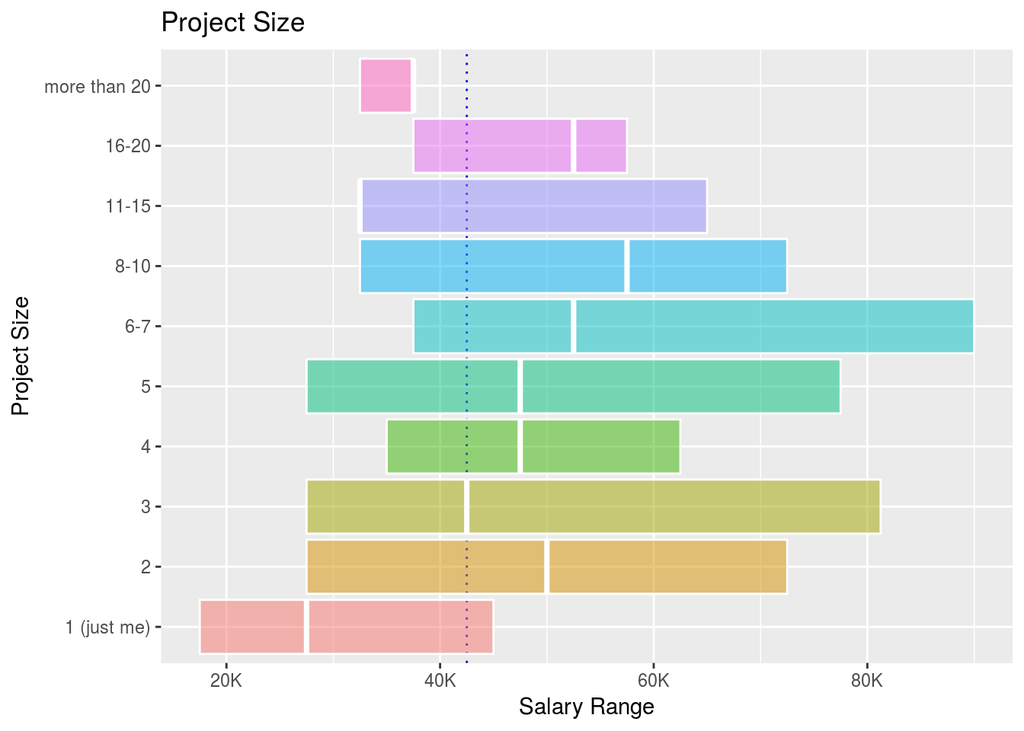

# Freelance and Independent Contractors

Freelancers or independent contractors made up only 9.86% of the respondents. As a group, freelancers enjoyed a Php 7,500 premium over employees.

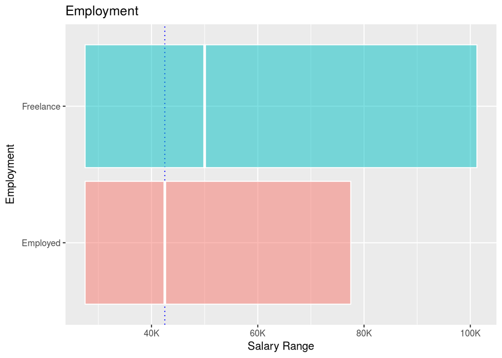